# Recombination maps analysis

Ruth Gómez Graciani

# El nostre mètode causa esbiaixos?

## Take samples

1-point vs proportional region 0-based coordinates assumed

## Statistics

**The paired T-test**

According to the statistics manual:

“Use the paired t–test when you have one measurement variable and two nominal variables, one of the nominal variables has only two values, and you only have one observation for each combination of the nominal variables; in other words, you have multiple pairs of observations.”

## Are values different depending on calculation method on window size?

Com es pot veure a la següent figura, no sembla haver-hi molta diferència en la taxa de recombinació amb les finestres grans, pero a mesura que disminuim la mida de finestra augmenta la probabilitat del metode del paper de tenir valors equivalents a 0, el que podria donar problemes a causa de diferncies extremes entre els calculs d’un i l’altre metode.

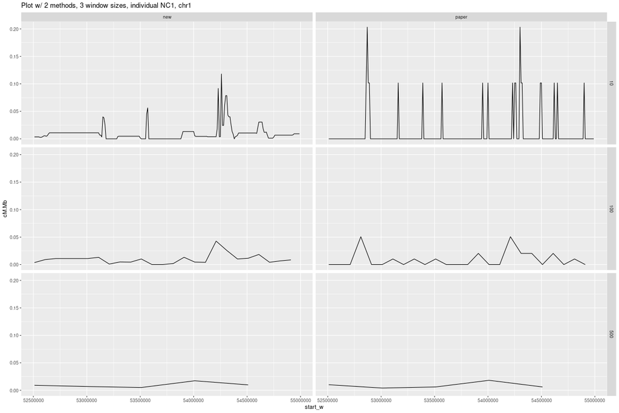

Figure 1

Per veure si el metode que triem afecta al resultat, farem un paired t-test, que hauria de ser mes significatiu com mes petita la mida de finestra.

```
## [1] "Now doing test with WINDOW SIZE = 500kb"
```

```
##
##  Paired t-test
##
## data:  subset.paired$new and subset.paired$paper
## t = 0.47143, df = 114759, p-value = 0.6373
## alternative hypothesis: true difference in means is not equal to 0
## 95 percent confidence interval:
##  -1.288542e-05  2.104706e-05
## sample estimates:
## mean of the differences
##            4.080819e-06
```

```
## [1] "Now doing test with WINDOW SIZE = 100kb"
```

```
##
##  Paired t-test
##
## data:  subset.paired$new and subset.paired$paper
## t = 0.74159, df = 574659, p-value = 0.4583
## alternative hypothesis: true difference in means is not equal to 0
## 95 percent confidence interval:
##  -1.334234e-05  2.958463e-05
## sample estimates:
## mean of the differences
##            8.121145e-06
```

```
## [1] "Now doing test with WINDOW SIZE = 10kb"
```

```
##
##  Paired t-test
##
## data:  subset.paired$new and subset.paired$paper
## t = 0.62202, df = 5748859, p-value = 0.5339
## alternative hypothesis: true difference in means is not equal to 0
## 95 percent confidence interval:
##  -1.412084e-05  2.725049e-05
## sample estimates:
## mean of the differences
##            6.564823e-06
```

Per veure que la mida de finestra no estigui afegint cap esbiaix, simplement compararia les diferents mides de finestra 2 a 2, pero no se com combinar cada 5 valors de 100kb per fer la mitjana en 500kb etc.

Com a molt, he pogut veure que passa quan faig la mitjana dels cromosomes per cada mètode i mida de finestra:

```
## [1] "Now doing test with WINDOW SIZE = 500kb"
```

```
##
##  Paired t-test
##
## data:  subset.paired$new and subset.paired$paper
## t = 9.5351, df = 439, p-value < 2.2e-16
## alternative hypothesis: true difference in means is not equal to 0
## 95 percent confidence interval:
##  3.667007e-06 5.571196e-06
## sample estimates:
## mean of the differences
##            4.619101e-06
```

```
## [1] "Now doing test with WINDOW SIZE = 100kb"
```

```
##
##  Paired t-test
##
## data:  subset.paired$new and subset.paired$paper
## t = 24.04, df = 439, p-value < 2.2e-16
## alternative hypothesis: true difference in means is not equal to 0
## 95 percent confidence interval:
##  8.747528e-06 1.030518e-05
## sample estimates:
## mean of the differences
##            9.526355e-06
```

```
## [1] "Now doing test with WINDOW SIZE = 10kb"
```

```
##
##  Paired t-test
##
## data:  subset.paired$new and subset.paired$paper
## t = 52.222, df = 439, p-value < 2.2e-16
## alternative hypothesis: true difference in means is not equal to 0
## 95 percent confidence interval:
##  7.006611e-06 7.554631e-06
## sample estimates:
## mean of the differences
##            7.280621e-06
```

Hi ha diferncies significatives entre metodes en la taxa mitjana del cromosoma, sigui quina sigui la mida de finestra.

```
## [1] "Now doing test with WINDOW SIZES = 500kb and 100kb"
```

```
##
##  Paired t-test
##
## data:  subset.paired[, as.character(winsize1)] and subset.paired[, as.character(winsize2)]
## t = -45.069, df = 879, p-value < 2.2e-16
## alternative hypothesis: true difference in means is not equal to 0
## 95 percent confidence interval:
##  -1.020956e-04 -9.357454e-05
## sample estimates:
## mean of the differences
##           -9.783508e-05
```

```
## [1] "Now doing test with WINDOW SIZES = 100kb and 10kb"
```

```
##
##  Paired t-test
##
## data:  subset.paired[, as.character(winsize1)] and subset.paired[, as.character(winsize2)]
## t = -37.697, df = 879, p-value < 2.2e-16
## alternative hypothesis: true difference in means is not equal to 0
## 95 percent confidence interval:
##  -2.927392e-05 -2.637656e-05
## sample estimates:
## mean of the differences
##           -2.782524e-05
```

Hi ha diferencies significatives entre mides de finestra en la taxa mitjana del cromosoma, independentment del metode que s’hagi fet servir. Aquests esbiaixos son possiblement causats perque com més petita la mida de finestra, i especialment en el cas del metode fet servir enl’article original, mes finestres amb un valor de 0 hi ha. Aquest es un exemple simple de per que seria millor calcular directament els intervals que volem, enlloc de fer les mitjanes de finestres fixes preestablertes al llarg d’una regio.

# Hi ha diferncies en la taxa de recombinació dins vs. fora de les inversions?

## Text

He fet servir totes les coordenades que he trobat en hg38.

La HsInv0573 y HsInv0786 haurien d’estar dividides en més finestres per un estudi mes exhaustiu, per exemple en finestres de 10kb amb 100kb a banda i banda.

> > Afegir anotació sobre com era el filtratge dels genotips, recordo que era un metode mes laxe, pero potser s’hauria de revisar perque es saltava la 786 encara que una poblacio era imputable. Iputació HsInv0501!!

## Big inversions study

A la Figura 2 podem observar que la inversió HsInv0573 no presenta un escenari gaire variat al seu voltant i no hi podrem observar res. A la HsInv0786 es poden veure mes canvis i sebla que alguns tindrien una resolucio bastant fina, donat que es poden veure alguns pics concrets. Em centraré llavors en aquesta inversio.

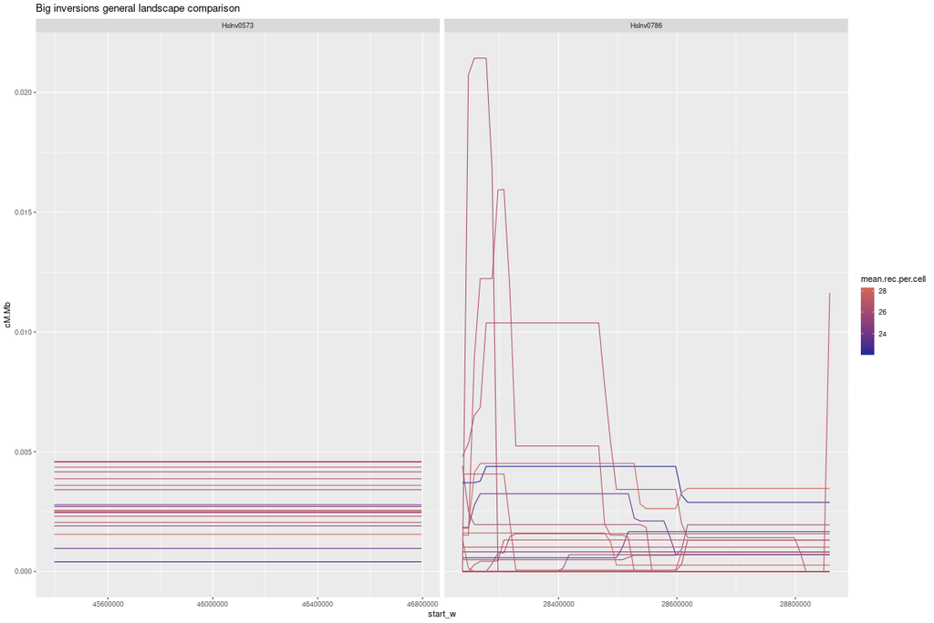

Figure 2

Tinc genotips aparentment de bona qualitat per varies poblacions, pero nomes els europeus consten com realment imputables.

En la figura 3 es pot veure com es la situacio al voltant de la inversio. Els unics genotips fiables realment, com ja he dit, son els dels europeus. L’individu europeu marcat amb la linia de punts es heterozigot quan sel compara amb tots els altres europeus, i invertit quan sel compara amb els individus de la poblacio general mes semblants a ell.

Aquesta figura no ha estat normalitzada per poder veure els efectes de diferents metodes de normalitzacio en les seguents figures. En endavant nomes es miraran individus europeus.

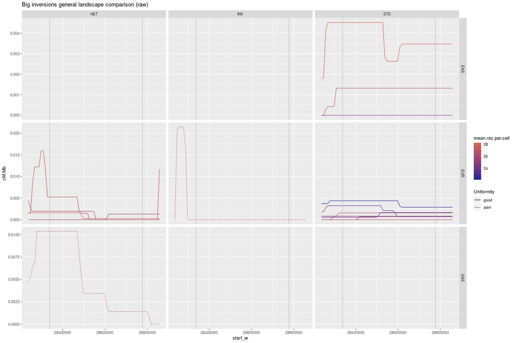

Figure 3

**Comparacio de diferents metodes de normalitzacio**

En general, la normalització no afecta molt a la forma de la distribucio, pero si als valors que agafa tot i que canvien molt lleuregament.

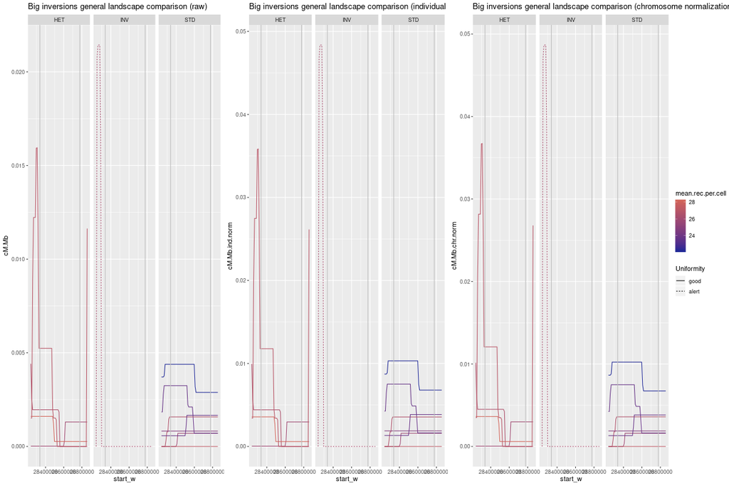

Figure 4

**Comparacio dins vs. fora, que passa quan excloem (o no) 20kb a banda i banda?**

```
##     ind mean.rec.per.cell Genotype_500   excl.20   incl.20
## 1   NC1          26.31263          INV 0.0000000 0.0000000
## 2  NC11          25.82228          STD 1.6091067 1.6091067
## 3  NC12          23.75524          STD 1.1720011 1.1380080
## 4  NC13          27.18758          STD 1.0000000 1.0000000
## 5  NC14          26.65195          STD 1.8171979 1.6186254
## 6  NC15          24.79671          STD 1.0000000 1.0000000
## 7  NC16          23.77591          STD 1.0843748 1.0843748
## 8  NC17          25.92287          HET 0.7286311 0.7286311
## 9  NC18          26.48395          HET 0.8364142 0.8711935
## 10  NC2          22.18810          STD 1.1100488 1.0966632
## 11  NC3          28.13344          HET 0.8160816 0.8160816
## 12  NC4          26.98381          HET 0.3535716 0.3333083
```

```
##
##  Welch Two Sample t-test
##
## data:  ratios$incl.20 and ratios$excl.20
## t = -0.099719, df = 21.917, p-value = 0.9215
## alternative hypothesis: true difference in means is not equal to 0
## 95 percent confidence interval:
##  -0.4204743  0.3819017
## sample estimates:
## mean of x mean of y
## 0.9413327 0.9606190
```

En la següent figura, es poden veure els canvis en context.

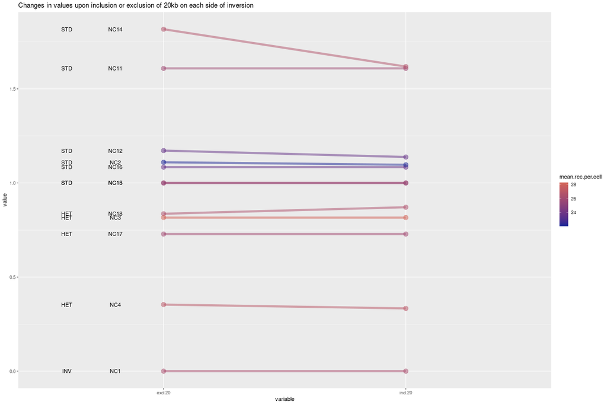

Figure 5

# La resta d’inversions

Aquestes mesures de recombinació s’han fet d’acord amb l’apres a l’exemple anterior: ens hem saltat les 20kb immediatament properes a la inversio i hem tingut en compte 50kb d’interval de confiança un cop passades aquestes 20kb. S’ha normalitzat les ratios dividint-les per la taxa de recombinacio mitjana per cromosoma i individu.

> - Nota: lo del cromosoma crec que es important perque en algun moment vaig veure els cromosomes tenint moltes diferencies entre ells en aquestes dades…

La taxa dins, a l’esquerra i a la dreta de la inversió s’ha calculat com 3 blocs.

```
## [1] "Now doing test with GENOTYPE = INV"
```

```
##
##  Welch Two Sample t-test
##
## data:  recMap.i$out and recMap.i[, "in"]
## t = -0.9014, df = 197.76, p-value = 0.3685
## alternative hypothesis: true difference in means is not equal to 0
## 95 percent confidence interval:
##  -0.019129990  0.007127787
## sample estimates:
##  mean of x  mean of y
## 0.02131164 0.02731274
```

```
## [1] "Now doing test with GENOTYPE = HET"
```

```
##
##  Welch Two Sample t-test
##
## data:  recMap.i$out and recMap.i[, "in"]
## t = -0.31099, df = 393.9, p-value = 0.756
## alternative hypothesis: true difference in means is not equal to 0
## 95 percent confidence interval:
##  -0.007587474  0.005514901
## sample estimates:
##  mean of x  mean of y
## 0.01795232 0.01898860
```

```
## [1] "Now doing test with GENOTYPE = STD"
```

```
##
##  Welch Two Sample t-test
##
## data:  recMap.i$out and recMap.i[, "in"]
## t = -0.028882, df = 1309.7, p-value = 0.977
## alternative hypothesis: true difference in means is not equal to 0
## 95 percent confidence interval:
##  -0.004087271  0.003968670
## sample estimates:
##  mean of x  mean of y
## 0.01920992 0.01926922
```

I tambe puc representar-ho graficament:

Hi han 68 inversions

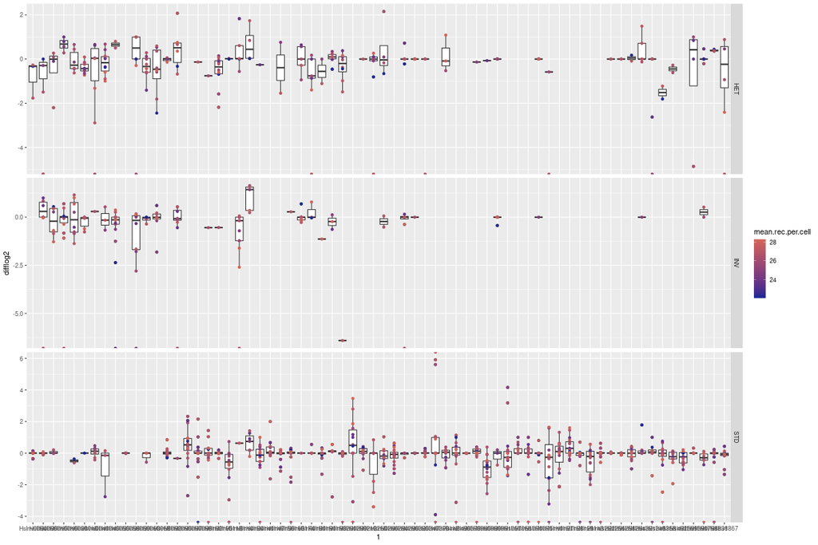

Figure 6

[output not shown]